# Zeyuan Dong -510 Final Project

Zeyuan Dong

11/17/2020

# RNA-seq Analysis of bladder cancer in White and Asian Male population

## Data

- From the national cancer institute GDC data portal (https://portal.gdc.cancer.gov/), I have downloaded the publicly available data sets.
- Cancer：Bladder
- Program：TCGA
- Project：TCGA-BLCA
- Disease Type：Transitional cell papillomas and carcinomas
- Age at diagnosis ：From 34-90
- Vital Status：Alive
- In this case, there are only four samples of Asian women, so I planned to conduct RNA-Seq Analysis of Cancer in White and Asian Male population, thus dividing the data into two groups—White male and Asian male. I selected 34 data points for each group, including 30 men and four women.

## References/Links to Vignettes

- Law CW, Alhamdoosh M, Su S et al. RNA-seq analysis is easy as 1-2-3 with limma, Glimma and edgeR [version 3; peer review: 3 approved]. F1000Research 2018, 5:1408 https://www.bioconductor.org/packages/devel/workflows/vignettes/RNAseq123/inst/doc/limmaWorkflow.html

## Part 1 - set up

```r
#if (!requireNamespace("BiocManager", quietly = TRUE))
#    install.packages("BiocManager")
#BiocManager::install("Glimma")
#BiocManager::install("limma")
#BiocManager::install("edgeR")
#BiocManager::install("Homo.sapiens")
#BiocManager::install("stringr")
library(limma)
library(Glimma)
library(edgeR)
library(Homo.sapiens)#for human genes
library(stringr)
setwd('/Users/dongzeyuan/Desktop/zeyuan-510final')
```

## Part 2 - Unzip

```r
# unzip whitemale data
setwd('/Users/dongzeyuan/Desktop/zeyuan-510final/WhiteMale')
dir.create("SampleFiles")
filepath <- dir(path ="./gdc_download_20201111_071754.200344",full.names = TRUE)
for(wd in filepath){
  files <-dir(path = wd,pattern="gz$") #
  fromfilepath <- paste(wd,"/",files,sep ="")
  tofilepath <- paste("./SampleFiles/",files,sep ="")
  file.copy(fromfilepath,tofilepath)
}

# unzip whitefemale data
setwd('/Users/dongzeyuan/Desktop/zeyuan-510final/WhiteFemale')
dir.create("SampleFiles2")
filepath <- dir(path ="./gdc_download_20201111_071940.367741",full.names = TRUE)
for(wd in filepath){
  files <-dir(path = wd,pattern="gz$")
  fromfilepath <- paste(wd,"/",files,sep ="")
  tofilepath <- paste("./SampleFiles2/",files,sep ="")
  file.copy(fromfilepath,tofilepath)
}

# unzip asianfemale data
setwd('/Users/dongzeyuan/Desktop/zeyuan-510final/AsianFemale')
dir.create("SampleFiles3")
filepath <- dir(path ="./gdc_download_20201111_071444.004912",full.names = TRUE)
for(wd in filepath){
  files <-dir(path = wd,pattern="gz$")
  fromfilepath <- paste(wd,"/",files,sep ="")
  tofilepath <- paste("./SampleFiles3/",files,sep ="")
  file.copy(fromfilepath,tofilepath)
}

# unzip asianmale data
setwd('/Users/dongzeyuan/Desktop/zeyuan-510final/AsianMale')
dir.create("SampleFiles4")
filepath <- dir(path ="./gdc_download_20201111_071307.660905",full.names = TRUE)
for(wd in filepath){
  files <-dir(path = wd,pattern="gz$")
  fromfilepath <- paste(wd,"/",files,sep ="")
  tofilepath <- paste("./SampleFiles4/",files,sep ="")
  file.copy(fromfilepath,tofilepath)
}
# Check Files and manuanlly unzip desired data
```

## Part 3 - Rename and transfer files to working directory

```r
#tarDir <- "/Users/dongzeyuan/Desktop/zeyuan-510final/TwoGroups"
#dir.create(tarDir)

#setwd("/Users/dongzeyuan/Desktop/zeyuan-510final/TwoGroups")
#old_files1 <- list.files("/Users/dongzeyuan/Desktop/zeyuan-510final/WhiteMale/SampleFiles", pattern = ".htseq.counts", full.names = TRUE)
#new_files1 <- c("WM01.htseq.counts",
#"WM02.htseq.counts",
#"WM03.htseq.counts",
#"WM04.htseq.counts",
#"WM05.htseq.counts",
#"WM06.htseq.counts",
#"WM07.htseq.counts",
#"WM08.htseq.counts",
#"WM09.htseq.counts",
#"WM10.htseq.counts",
#"WM11.htseq.counts",
#"WM12.htseq.counts",
#"WM13.htseq.counts",
#"WM14.htseq.counts",
#"WM15.htseq.counts",
#"WM16.htseq.counts",
#"WM17.htseq.counts",
#"WM18.htseq.counts",
#"WM19.htseq.counts",
#"WM20.htseq.counts",
#"WM21.htseq.counts",
#"WM22.htseq.counts",
#"WM23.htseq.counts",
#"WM24.htseq.counts",
#"WM25.htseq.counts",
#"WM26.htseq.counts",
#"WM27.htseq.counts",
#"WM28.htseq.counts",
#"WM29.htseq.counts",
#"WM30.htseq.counts")

#file.copy(from = old_files1, to = new_files1)


#old_files2 <- list.files("/Users/dongzeyuan/Desktop/zeyuan-510final/WhiteFemale/SampleFiles2", pattern = ".htseq.counts", full.names = TRUE)
#new_files2 <- c("WF01.htseq.counts",
#"WF02.htseq.counts",
#"WF03.htseq.counts",
#"WF04.htseq.counts")

#file.copy(from = old_files2, to = new_files2)

#old_files3 <- list.files("/Users/dongzeyuan/Desktop/zeyuan-510final/AsianFemale/SampleFiles3", pattern = ".htseq.counts", full.names = TRUE)
#new_files3 <- c("AF01.htseq.counts",
#"AF02.htseq.counts",
#"AF03.htseq.counts",
#"AF04.htseq.counts")

#file.copy(from = old_files3, to = new_files3)


#old_files4 <- list.files("/Users/dongzeyuan/Desktop/zeyuan-510final/AsianMale/SampleFiles4", pattern = ".htseq.counts", full.names = TRUE)
#new_files4 <- c("AM01.htseq.counts",
#"AM02.htseq.counts",
#"AM03.htseq.counts",
#"AM04.htseq.counts",
#"AM05.htseq.counts",
#"AM06.htseq.counts",
#"AM07.htseq.counts",
#"AM08.htseq.counts",
#"AM09.htseq.counts",
#"AM10.htseq.counts",
#"AM11.htseq.counts",
#"AM12.htseq.counts",
#"AM13.htseq.counts",
#"AM14.htseq.counts",
#"AM15.htseq.counts",
#"AM16.htseq.counts",
#"AM17.htseq.counts",
#"AM18.htseq.counts",
#"AM19.htseq.counts",
#"AM20.htseq.counts",
#"AM21.htseq.counts",
#"AM22.htseq.counts",
#"AM23.htseq.counts",
#"AM24.htseq.counts",
#"AM25.htseq.counts",
#"AM26.htseq.counts",
#"AM27.htseq.counts",
#"AM28.htseq.counts",
#"AM29.htseq.counts",
#"AM30.htseq.counts")

#file.copy(from = old_files4, to = new_files4)
```

## Part 4 - Reading in counts data via readDGE

```r
setwd('/Users/dongzeyuan/Desktop/zeyuan-510final/TwoGroups')
files <- c("WM01.htseq.counts","WM02.htseq.counts","WM03.htseq.counts","WM04.htseq.counts","WM05.htseq.counts","WM06.htseq.counts","WM07.htseq.counts","WM08.htseq.counts","WM09.htseq.counts","WM10.htseq.counts","WM11.htseq.counts","WM12.htseq.counts","WM13.htseq.counts","WM14.htseq.counts","WM15.htseq.counts","WM16.htseq.counts","WM17.htseq.counts","WM18.htseq.counts","WM19.htseq.counts","WM20.htseq.counts","WM21.htseq.counts","WM22.htseq.counts","WM23.htseq.counts","WM24.htseq.counts","WM25.htseq.counts","WM26.htseq.counts","WM27.htseq.counts","WM28.htseq.counts","WM29.htseq.counts","WM30.htseq.counts","WF01.htseq.counts","WF02.htseq.counts","WF03.htseq.counts","WF04.htseq.counts","AF01.htseq.counts","AF02.htseq.counts","AF03.htseq.counts","AF04.htseq.counts","AM01.htseq.counts","AM02.htseq.counts","AM03.htseq.counts","AM04.htseq.counts","AM05.htseq.counts","AM06.htseq.counts","AM07.htseq.counts","AM08.htseq.counts","AM09.htseq.counts","AM10.htseq.counts","AM11.htseq.counts","AM12.htseq.counts","AM13.htseq.counts","AM14.htseq.counts","AM15.htseq.counts","AM16.htseq.counts","AM17.htseq.counts","AM18.htseq.counts","AM19.htseq.counts","AM20.htseq.counts","AM21.htseq.counts","AM22.htseq.counts","AM23.htseq.counts","AM24.htseq.counts","AM25.htseq.counts","AM26.htseq.counts","AM27.htseq.counts","AM28.htseq.counts","AM29.htseq.counts","AM30.htseq.counts")
#for(i in paste(files, ".gz", sep=""))
#  R.utils::gunzip(i, overwrite=TRUE)

x <- readDGE(files, columns=c(1,2))
```

```
## Meta tags detected: __no_feature, __ambiguous, __too_low_aQual, __not_aligned, __alignment_not_unique
```

**males only**

```r
setwd('/Users/dongzeyuan/Desktop/zeyuan-510final/TwoGroups')
files_male_only <- c("WM01.htseq.counts","WM02.htseq.counts","WM03.htseq.counts","WM04.htseq.counts","WM05.htseq.counts","WM06.htseq.counts","WM07.htseq.counts","WM08.htseq.counts","WM09.htseq.counts","WM10.htseq.counts","WM11.htseq.counts","WM12.htseq.counts","WM13.htseq.counts","WM14.htseq.counts","WM15.htseq.counts","WM16.htseq.counts","WM17.htseq.counts","WM18.htseq.counts","WM19.htseq.counts","WM20.htseq.counts","WM21.htseq.counts","WM22.htseq.counts","WM23.htseq.counts","WM24.htseq.counts","WM25.htseq.counts","WM26.htseq.counts","WM27.htseq.counts","WM28.htseq.counts","WM29.htseq.counts","WM30.htseq.counts","AM01.htseq.counts","AM02.htseq.counts","AM03.htseq.counts","AM04.htseq.counts","AM05.htseq.counts","AM06.htseq.counts","AM07.htseq.counts","AM08.htseq.counts","AM09.htseq.counts","AM10.htseq.counts","AM11.htseq.counts","AM12.htseq.counts","AM13.htseq.counts","AM14.htseq.counts","AM15.htseq.counts","AM16.htseq.counts","AM17.htseq.counts","AM18.htseq.counts","AM19.htseq.counts","AM20.htseq.counts","AM21.htseq.counts","AM22.htseq.counts","AM23.htseq.counts","AM24.htseq.counts","AM25.htseq.counts","AM26.htseq.counts","AM27.htseq.counts","AM28.htseq.counts","AM29.htseq.counts","AM30.htseq.counts")

x_male_only <-readDGE(files_male_only, columns=c(1,2))
```

```
## Meta tags detected: __no_feature, __ambiguous, __too_low_aQual, __not_aligned, __alignment_not_unique
```

## Part 5 - Data Sorting

```r
# strip the suffix
samplenames <-  substring(colnames(x), 1, 4)
samplenames
```

```
##  [1] "WM01" "WM02" "WM03" "WM04" "WM05" "WM06" "WM07" "WM08" "WM09" "WM10"
## [11] "WM11" "WM12" "WM13" "WM14" "WM15" "WM16" "WM17" "WM18" "WM19" "WM20"
## [21] "WM21" "WM22" "WM23" "WM24" "WM25" "WM26" "WM27" "WM28" "WM29" "WM30"
## [31] "WF01" "WF02" "WF03" "WF04" "AF01" "AF02" "AF03" "AF04" "AM01" "AM02"
## [41] "AM03" "AM04" "AM05" "AM06" "AM07" "AM08" "AM09" "AM10" "AM11" "AM12"
## [51] "AM13" "AM14" "AM15" "AM16" "AM17" "AM18" "AM19" "AM20" "AM21" "AM22"
## [61] "AM23" "AM24" "AM25" "AM26" "AM27" "AM28" "AM29" "AM30"
```

```r
colnames(x) <- samplenames
```

```r
samplenames_males_only <-  substring(colnames(x_male_only), 1, 4)
#samplenames

colnames(x_male_only) <- samplenames_males_only
```

**Add ‘Race’ as a factor, consisting of White and Asian**

**Add ‘gender’ as a factor, similar to ‘Lane’ in the article, consisting of Males and Females.**

```r
# Group by Race
group <- as.factor(rep(c("White","Asian"),c(34,34)))
x$samples$group <- group

# Group by gender
gender <- as.factor(rep(c("Male","Female","Male"),c(30,8,30)))
x$samples$gender<-gender
```

```r
group_male_only <- as.factor(rep(c("White","Asian"),c(30,30)))
x_male_only$samples$group <- group_male_only

gender_male_only <- as.factor(rep(c("Male","Male"),c(30,30)))
x_male_only$samples$gender<-gender_male_only
```

```r
# Look for the geneid corresponding gene-symbols and locations of chromosome
geneid <- rownames(x)
#geneid
# Remove the decimal point at ENSEMBL
gene <- str_match(geneid, "(\\w*).*")
geneid <- gene[,2]
# go through Homo pacakge and get symbol and chromosome location
genes <- select(Homo.sapiens,
                keys=geneid,
                columns=c("SYMBOL","TXCHROM"),
                keytype="ENSEMBL")
head(genes)
```

```
##           ENSEMBL   SYMBOL TXCHROM
## 1 ENSG00000000005     TNMD    chrX
## 2 ENSG00000000419     DPM1   chr20
## 3 ENSG00000000457    SCYL3    chr1
## 4 ENSG00000000460 C1orf112    chr1
## 5 ENSG00000000938      FGR    chr1
## 6 ENSG00000000971      CFH    chr1
```

```r
# remove the overlapped genes
genes <- genes[!duplicated(genes$ENSEMBL),]
# import genes to DGEList
x$genes <- genes
#x
```

```r
# Look for the geneid corresponding gene-symbols and locations of chromosome
geneid_male_only <- rownames(x_male_only)
#geneid
# Remove the decimal point at ENSEMBL
gene_male_only <- str_match(geneid_male_only, "(\\w*).*")
geneid_male_only <- gene_male_only[,2]
# go through Homo pacakge and get symbol and chromosome location
genes_male_only <- select(Homo.sapiens,
                keys=geneid,
                columns=c("SYMBOL","TXCHROM"),
                keytype="ENSEMBL")
#head(genes_male_only)
# remove the overlapped genes
genes_male_only <- genes_male_only[!duplicated(genes$ENSEMBL),]
# import genes to DGEList
x_male_only$genes <- genes_male_only
#x
```

## Part 6 - Data preprocessing

```r
cpm <- cpm(x)
lcpm <- cpm(x, log=TRUE)
```

```r
cpm_male_only <- cpm(x_male_only)
lcpm_male_only <- cpm(x_male_only, log=TRUE)
```

```r
# Get the average and median of the sample library size
L <- mean(x$samples$lib.size) * 1e-6
M <- median(x$samples$lib.size) * 1e-6
c(L, M)
```

```
## [1] 80.27711 75.63755
```

```r
# Get the average and median of the sample library size
L_male_only <- mean(x_male_only$samples$lib.size) * 1e-6
M_male_only <- median(x_male_only$samples$lib.size) * 1e-6
#c(L, M)
```

```r
# see the summary
summary(lcpm)
```

```
##       WM01              WM02              WM03              WM04
##  Min.   :-5.3269   Min.   :-5.3269   Min.   :-5.3269   Min.   :-5.3269
##  1st Qu.:-5.3269   1st Qu.:-5.3269   1st Qu.:-5.3269   1st Qu.:-5.3269
##  Median :-5.3269   Median :-4.6226   Median :-4.5340   Median :-4.5704
##  Mean   :-2.6314   Mean   :-2.5396   Mean   :-2.3890   Mean   :-2.4082
##  3rd Qu.:-0.4149   3rd Qu.:-0.4529   3rd Qu.:-0.2724   3rd Qu.:-0.1645
##  Max.   :17.7454   Max.   :17.9583   Max.   :17.4635   Max.   :17.8388
##       WM05               WM06              WM07              WM08
##  Min.   :-5.32692   Min.   :-5.3269   Min.   :-5.3269   Min.   :-5.3269
##  1st Qu.:-5.32692   1st Qu.:-5.3269   1st Qu.:-5.3269   1st Qu.:-5.3269
##  Median :-4.80685   Median :-4.7634   Median :-4.6601   Median :-4.8768
##  Mean   :-2.41955   Mean   :-2.6985   Mean   :-2.4729   Mean   :-2.6704
##  3rd Qu.:-0.06668   3rd Qu.:-0.9969   3rd Qu.:-0.2688   3rd Qu.:-0.9503
##  Max.   :18.52531   Max.   :17.9985   Max.   :17.8434   Max.   :18.1149
##       WM09              WM10              WM11              WM12
##  Min.   :-5.3269   Min.   :-5.3269   Min.   :-5.3269   Min.   :-5.3269
##  1st Qu.:-5.3269   1st Qu.:-5.3269   1st Qu.:-5.3269   1st Qu.:-5.3269
##  Median :-5.3269   Median :-4.7118   Median :-5.3269   Median :-5.3269
##  Mean   :-2.5955   Mean   :-2.5468   Mean   :-2.6742   Mean   :-2.6826
##  3rd Qu.:-0.6431   3rd Qu.:-0.4083   3rd Qu.:-0.7364   3rd Qu.:-0.9285
##  Max.   :17.5749   Max.   :17.5749   Max.   :17.9109   Max.   :17.8394
##       WM13             WM14               WM15              WM16
##  Min.   :-5.327   Min.   :-5.32692   Min.   :-5.3269   Min.   :-5.327
##  1st Qu.:-5.327   1st Qu.:-5.32692   1st Qu.:-5.3269   1st Qu.:-5.327
##  Median :-4.655   Median :-4.63508   Median :-5.3269   Median :-5.327
##  Mean   :-2.560   Mean   :-2.43548   Mean   :-2.5495   Mean   :-2.655
##  3rd Qu.:-0.446   3rd Qu.:-0.01343   3rd Qu.:-0.4172   3rd Qu.:-0.967
##  Max.   :17.770   Max.   :17.94493   Max.   :17.5603   Max.   :17.344
##       WM17              WM18              WM19              WM20
##  Min.   :-5.3269   Min.   :-5.3269   Min.   :-5.3269   Min.   :-5.3269
##  1st Qu.:-5.3269   1st Qu.:-5.3269   1st Qu.:-5.3269   1st Qu.:-5.3269
##  Median :-4.6507   Median :-4.7548   Median :-4.8064   Median :-4.6185
##  Mean   :-2.5070   Mean   :-2.4360   Mean   :-2.5228   Mean   :-2.2647
##  3rd Qu.:-0.5244   3rd Qu.:-0.1169   3rd Qu.:-0.5684   3rd Qu.: 0.3118
##  Max.   :17.8456   Max.   :18.1089   Max.   :17.7854   Max.   :17.7193
##       WM21              WM22              WM23             WM24
##  Min.   :-5.3269   Min.   :-5.3269   Min.   :-5.327   Min.   :-5.327
##  1st Qu.:-5.3269   1st Qu.:-5.3269   1st Qu.:-5.327   1st Qu.:-5.327
##  Median :-4.6693   Median :-4.9014   Median :-5.327   Median :-4.714
##  Mean   :-2.4430   Mean   :-2.5493   Mean   :-2.802   Mean   :-2.456
```

[output cut: 64 more lines]

```
##  Max.   :17.7992   Max.   :18.3595   Max.   :18.6399   Max.   :18.478
##       AM23             AM24              AM25             AM26
##  Min.   :-5.327   Min.   :-5.3269   Min.   :-5.327   Min.   :-5.3269
##  1st Qu.:-5.327   1st Qu.:-5.3269   1st Qu.:-5.327   1st Qu.:-5.3269
##  Median :-5.327   Median :-5.3269   Median :-4.436   Median :-4.6663
##  Mean   :-2.964   Mean   :-2.6495   Mean   :-2.386   Mean   :-2.5526
##  3rd Qu.:-1.422   3rd Qu.:-0.5852   3rd Qu.:-0.226   3rd Qu.:-0.3635
##  Max.   :18.269   Max.   :17.9668   Max.   :17.729   Max.   :18.0451
##       AM27             AM28              AM29             AM30
##  Min.   :-5.327   Min.   :-5.3269   Min.   :-5.327   Min.   :-5.3269
##  1st Qu.:-5.327   1st Qu.:-5.3269   1st Qu.:-5.327   1st Qu.:-5.3269
##  Median :-5.327   Median :-5.3269   Median :-5.327   Median :-4.7689
##  Mean   :-2.800   Mean   :-2.7496   Mean   :-2.820   Mean   :-2.4558
##  3rd Qu.:-1.028   3rd Qu.:-0.9491   3rd Qu.:-1.140   3rd Qu.:-0.2777
##  Max.   :17.949   Max.   :18.0113   Max.   :18.695   Max.   :17.5229
```

```r
#summary(lcpm_male_only)
```

```r
# to filter genes, while keeping as many genes as possible with worthwhile counts.
keep.exprs <- filterByExpr(x, group=group)
x <- x[keep.exprs,, keep.lib.sizes=FALSE]
dim(x)
```

```
## [1] 20138    68
```

```r
# to filter genes, while keeping as many genes as possible with worthwhile counts.
keep.exprs <- filterByExpr(x_male_only, group=group)
x_male_only <- x_male_only[keep.exprs,, keep.lib.sizes=FALSE]
#dim(x_male_only)
```

**Comparison of Raw data and filtered data**

```r
# Compare the data before and after filtering
lcpm.cutoff <- log2(5/M + 2/L)
library(RColorBrewer)
nsamples <- ncol(x)
col <- brewer.pal(nsamples, "Paired")
```

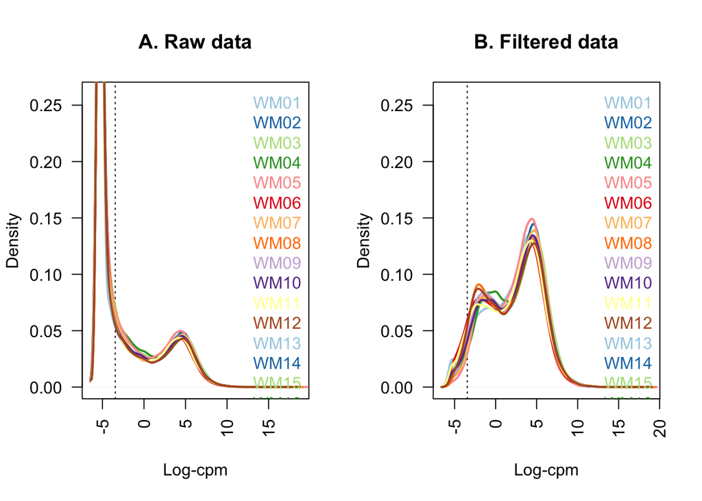

```r
par(mfrow=c(1,2))
plot(density(lcpm[,1]), col=col[1], lwd=2, ylim=c(0,0.26), las=2, main="", xlab="")
title(main="A. Raw data", xlab="Log-cpm")
abline(v=lcpm.cutoff, lty=3)
for (i in 2:nsamples){
den <- density(lcpm[,i])
lines(den$x, den$y, col=col[i], lwd=2)
}
legend("topright", samplenames, text.col=col, bty="n")
lcpm <- cpm(x, log=TRUE)
plot(density(lcpm[,1]), col=col[1], lwd=2, ylim=c(0,0.26), las=2, main="", xlab="")
title(main="B. Filtered data", xlab="Log-cpm")
abline(v=lcpm.cutoff, lty=3)
for (i in 2:nsamples){
den <- density(lcpm[,i])
lines(den$x, den$y, col=col[i], lwd=2)
}
legend("topright", samplenames, text.col=col, bty="n")
```

```r
lcpm_male_only.cutoff <- log2(5/M + 2/L)
lcpm_male_only <- cpm(x_male_only, log=TRUE)
```

```r
# normalization
x <- calcNormFactors(x, method = "TMM")
x$samples$norm.factors
```

```
##  [1] 0.9906711 1.1128612 1.2862404 1.1637129 0.9685468 0.8655872 1.1624764
##  [8] 0.9960807 1.1034987 1.1138525 0.9253751 1.0598805 0.9132135 1.1127265
## [15] 0.9570849 1.1136734 1.1194157 1.1416051 1.1210267 1.3611276 1.1907137
## [22] 1.0514294 0.7971595 1.1937833 1.1827919 1.0175912 1.0532701 0.3703736
## [29] 1.3687501 0.9834462 1.0066632 1.0079499 1.2806465 1.0120290 0.8116220
## [36] 1.2169187 1.1680961 1.2434374 1.0576294 0.9613168 0.8563864 1.1025868
## [43] 0.9498651 1.1407080 1.2936701 1.2823856 1.0368950 0.9188302 1.0105678
## [50] 0.8765149 0.6811246 0.9871650 0.9549061 1.2145905 1.0973692 0.7117738
## [57] 1.1288755 1.2203519 0.7962916 0.3952453 0.5630903 0.8561179 1.2654744
## [64] 0.9873156 0.8244647 0.9445294 0.7698379 1.2427766
```

```r
# normalization
x_male_only<- calcNormFactors(x_male_only, method = "TMM")
x_male_only$samples$norm.factors
```

```
##  [1] 1.0544366 1.1822699 1.3137869 1.1391922 1.0687850 0.8821556 1.2500826
##  [8] 0.9759027 1.0843602 1.1360980 0.9637187 1.0153952 0.9539888 1.2010249
## [15] 1.0505980 1.1013236 1.1095586 1.1299325 1.1235116 1.3849932 1.2458779
## [22] 1.0582072 0.7575622 1.2592716 1.2203626 1.0373030 1.0684191 0.3735070
## [29] 1.4049891 0.9967419 1.0516851 0.9154784 0.9122300 1.1127232 0.9251500
## [36] 1.1603052 1.3335247 1.3149238 1.0320941 0.9061980 0.9581156 0.8460191
## [43] 0.6855343 1.0368601 0.9706537 1.2266938 1.0733621 0.6817997 1.1573692
## [50] 1.2433194 0.7774294 0.3731171 0.5495819 0.8988362 1.2533254 1.0315463
## [57] 0.7788595 0.9374891 0.7741824 1.2904361
```

```r
# To give a better visual representation of the effects of normalisation, the data was duplicated then adjusted so that the counts of the first sample are reduced to 5% of their original values, and in the second sample they are inflated to be 5-times larger.
x2 <- x
x2$samples$norm.factors <- 1
x2$counts[,1] <- ceiling(x2$counts[,1]*0.05)
x2$counts[,2] <- x2$counts[,2]*5
```

**Comparison of unnormalised data and normalised data**

- Boxplots of log-CPM values displaying the expression distributions for ‘unnormalised data’ and ‘normalised data’ respectively.

```r
par(mfrow=c(1,2))
lcpm <- cpm(x2, log=TRUE)
boxplot(lcpm, las=2, col=col, main="")
title(main="A. Example: Unnormalised data",ylab="Log-cpm")
x2 <- calcNormFactors(x2)
x2$samples$norm.factors
```

```
##  [1] 0.06240712 5.50619855 1.31601164 1.16928053 1.02167803 0.86378941
##  [7] 1.19567682 1.01974874 1.10916962 1.13109466 0.90931476 1.04943861
## [13] 0.95473805 1.15803559 1.04964202 1.11633889 1.13669152 1.17265012
## [19] 1.13926357 1.41574855 1.20762870 1.08110764 0.81483561 1.21823370
## [25] 1.19402358 1.04324607 1.06618421 0.38185077 1.41023715 1.01427805
## [31] 1.00653393 1.02269599 1.29978858 0.99161931 0.81675714 1.24670532
## [37] 1.17386503 1.25571264 1.04720965 0.98072175 0.84671839 1.09670615
## [43] 0.96640510 1.13301635 1.32622946 1.35960194 1.01892413 0.92254800
## [49] 1.00068939 0.89716104 0.70388504 1.00144044 0.98062456 1.26415319
## [55] 1.11233774 0.71553871 1.13762498 1.23488358 0.80335275 0.39924271
## [61] 0.57635838 0.88887026 1.29163654 1.03118686 0.82952801 0.96506159
## [67] 0.78340100 1.32116348
```

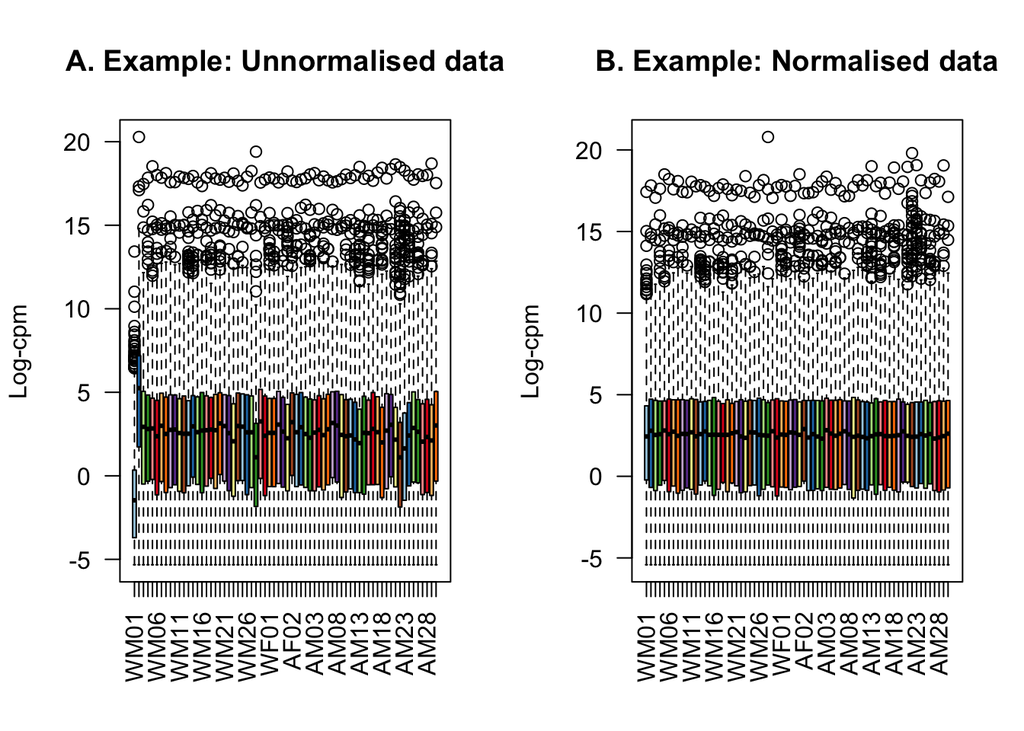

```r
lcpm <- cpm(x2, log=TRUE)
boxplot(lcpm, las=2, col=col, main="")
title(main="B. Example: Normalised data",ylab="Log-cpm")
```

## Part 7 - Unsupervised clustering of samples

**MDS plots of log-CPM values over dimensions-1 and 2 with samples coloured and labeled by race(White and Asian) while over dimensions-3 and 4 with samples coloured and labeled by gender(Male and Female). Distances on the plot is corresponding to the leading fold-change, i.e. the root-mean-square log 2-fold-change for the genes divergence between each pair of samples.**

**[Discussion] After cluster analysis, it can be seen from Figure A that the gene expression of most white people and Asian people is very different. As shown in Figure B, gender is not an important factor since the 8 points of female did not form a cluster although some points of males are clustered. Therefore, the differences in gene expression between white men and Asian men who have bladder cancer are regarded as my research interest, which could provide meaningful information.**

```r
# By Race
lcpm <- cpm(x, log=TRUE)
par(mfrow=c(1,2))
col.group <- group
levels(col.group) <-  brewer.pal(nlevels(col.group), "Set1")
```

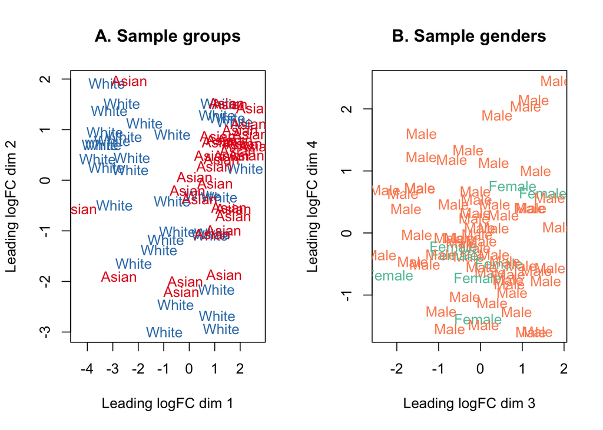

```r
col.group <- as.character(col.group)
plotMDS(lcpm, labels=group, col=col.group)
title(main="A. Sample groups")

# By gender
lcpm <- cpm(x, log=TRUE)

col.gender <- gender
levels(col.gender) <-  brewer.pal(nlevels(col.gender), "Set2")
col.gender <- as.character(col.gender)
plotMDS(lcpm, labels=gender, col=col.gender, dim=c(3,4))
title(main="B. Sample genders")
```

```r
# The glMDSPlot function generates an html page (that is opened in a browser if launch=TRUE) with an MDS plot in the left panel and a barplot showing the proportion of variation explained by each dimension in the right panel.
glMDSPlot(lcpm, groups=group,labels=paste(gender,sep="-"))
```

## Part 8 - Differential expression analysis

**From now, only males data for Differential expression analysis**

**The horizontal blue line marks the average log 2 residual standard deviation. Each black dot represents a gene and the red curve is fitted to these points.**

```r
# Creating a design matrix and contrasts
design <- model.matrix(~0+group_male_only)
colnames(design) <- gsub("group_male_only", "", colnames(design))
design
```

```
##    Asian White
## 1      0     1
## 2      0     1
## 3      0     1
## 4      0     1
## 5      0     1
## 6      0     1
## 7      0     1
## 8      0     1
## 9      0     1
## 10     0     1
## 11     0     1
## 12     0     1
## 13     0     1
## 14     0     1
```

[output cut: 51 more lines]

```r
contr.matrix <- makeContrasts(
   RaceVS= White - Asian,

   levels = colnames(design))
contr.matrix
```

```
##        Contrasts
## Levels  RaceVS
##   Asian     -1
##   White      1
```

```r
# Removing heteroscedascity from count data
par(mfrow=c(1,2))
v <- voom(x_male_only, design, plot=TRUE)
v
```

```
## An object of class "EList"
## $genes
##           ENSEMBL   SYMBOL TXCHROM
## 2 ENSG00000000419     DPM1   chr20
## 3 ENSG00000000457    SCYL3    chr1
## 4 ENSG00000000460 C1orf112    chr1
## 5 ENSG00000000938      FGR    chr1
## 6 ENSG00000000971      CFH    chr1
## 21047 more rows ...
##
## $targets
##                  files group  lib.size norm.factors gender
## WM01 WM01.htseq.counts White  40645743     1.054437   Male
## WM02 WM02.htseq.counts White  75282280     1.182270   Male
## WM03 WM03.htseq.counts White 143588616     1.313787   Male
## WM04 WM04.htseq.counts White 132364285     1.139192   Male
## WM05 WM05.htseq.counts White  98625108     1.068785   Male
## 55 more rows ...
##
## $E
##                     Samples
## Tags                     WM01     WM02     WM03       WM04     WM05     WM06
##   ENSG00000000419.11 5.022928 4.815950 5.672323  3.5510779 4.299073 5.490311
##   ENSG00000000457.12 1.758255 2.692058 2.877913  4.4705289 3.322292 3.105406
##   ENSG00000000460.15 1.579780 3.100035 2.661545  5.3134366 2.671886 3.358395
##   ENSG00000000938.11 3.275187 3.644579 2.618019 -0.1354808 3.098071 4.254403
##   ENSG00000000971.14 6.034617 5.118081 6.441128  1.4090108 5.292929 3.290239
##                     Samples
## Tags                     WM07     WM08     WM09     WM10     WM11     WM12
##   ENSG00000000419.11 4.999887 4.615341 4.746224 4.812657 4.677334 5.593602
##   ENSG00000000457.12 3.773436 4.004128 3.940233 2.721965 2.785133 5.231865
##   ENSG00000000460.15 3.019051 1.769489 2.511780 3.121264 2.549808 4.351631
##   ENSG00000000938.11 2.220277 3.448921 2.080104 2.820734 3.781998 1.948287
##   ENSG00000000971.14 6.211973 6.439701 2.894367 3.799699 5.907419 3.362123
##                     Samples
## Tags                     WM13     WM14     WM15     WM16     WM17     WM18
##   ENSG00000000419.11 4.323134 4.565077 4.667833 4.711618 4.194247 3.720298
##   ENSG00000000457.12 4.169448 3.277604 2.599264 3.414864 4.025844 3.081103
##   ENSG00000000460.15 4.104382 2.901658 1.243503 3.206667 4.101243 1.405411
##   ENSG00000000938.11 1.968313 2.143140 3.166926 3.237314 1.868074 2.008789
```

[output cut: 96 more lines]

```
## [1,] 1.7229362 2.281186 2.0142445 1.7265181 1.7714544 1.9894368 2.255054
## [2,] 1.3144743 1.997106 1.6122051 1.3175220 1.3579566 1.5805876 1.946586
## [3,] 0.8169787 1.216243 0.9522975 0.8182420 0.8350345 0.9363428 1.172435
## [4,] 0.9916849 1.566217 1.2024870 0.9936341 1.0200571 1.1784550 1.511324
## [5,] 2.3160791 2.431013 2.4068464 2.3173514 2.3339706 2.4007503 2.432541
## 19785 more rows ...
##
## $design
##   Asian White
## 1     0     1
## 2     0     1
## 3     0     1
## 4     0     1
## 5     0     1
## 55 more rows ...
```

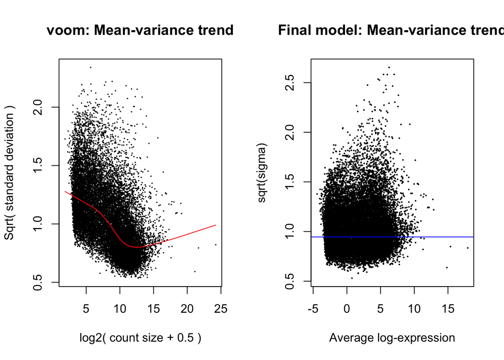

```r
vfit <- lmFit(v, design)
vfit <- contrasts.fit(vfit, contrasts=contr.matrix)
efit <- eBayes(vfit)
plotSA(efit, main="Final model: Mean-variance trend")
```

```r
# Examining the number of DE genes
summary(decideTests(efit, p.value = 0.05))# significance: p.value=0.05
```

```
##        RaceVS
## Down     2616
## NotSig  14857
## Up       2317
```

```r
tfit <- treat(vfit, lfc=log2(1.8))# To get more differentially expressed  genes via using log2(1.8) instead of log2(2); log2(1.8) is still acceptable and relatively reliable compared with log2(1.5) or log2(1.2).
dt <- decideTests(tfit, p.value=0.05)
summary(dt)
```

```
##        RaceVS
## Down       15
## NotSig  19763
## Up         12
```

```r
tfit <- treat(vfit, lfc=log2(1.8))
dt <- decideTests(tfit, p.value = 0.05)
summary(dt)
```

```
##        RaceVS
## Down       15
## NotSig  19763
## Up         12
```

**From data on UniProt, I hold the idea that SEMA4D is the most related to bladder cancer because it is a cell surface receptor that plays a role in cell-cell signaling. Whatsmore, it can induce endothelial cell migration via activating PTK2B/PYK2 pathway and other kinase-AKT pathways.**

**TANC1 is a scaffold component related to the nervous system. There is limited information about RPL32P1, but we know that this gene encodes a ribosomal protein, which is highly related to protein translation and metabolism.**

**KRTAP12-3 is not so important as the other genes. This is because its function is more related to hair keratin only.**

```r
# Examining individual DE genes from top to bottom
RaceVS <- topTreat(tfit, coef=1, n=Inf)
head(RaceVS)
```

```
##                            ENSEMBL    SYMBOL TXCHROM     logFC    AveExpr
## ENSG00000207425.1  ENSG00000205439 KRTAP12-3   chr21  3.872097 -2.7708182
## ENSG00000115414.17 ENSG00000115183     TANC1    chr2  3.241314  7.4604693
## ENSG00000226278.1  ENSG00000224796   RPL32P1    <NA> -5.094902 -1.4026288
## ENSG00000271579.1  ENSG00000268996 MAN1B1-DT    chr9 -4.215592 -1.7453452
## ENSG00000221947.6  ENSG00000217769      <NA>    <NA>  2.775228 -0.6783404
## ENSG00000188573.7  ENSG00000187764    SEMA4D    chr9 -3.294317 -1.3883600
##                            t      P.Value   adj.P.Val
## ENSG00000207425.1   5.701528 1.779808e-07 0.003522240
## ENSG00000115414.17  5.349273 6.809986e-07 0.006738481
## ENSG00000226278.1  -5.040873 2.157664e-06 0.008956744
## ENSG00000271579.1  -5.034672 2.206950e-06 0.008956744
## ENSG00000221947.6   5.027882 2.262947e-06 0.008956744
## ENSG00000188573.7  -4.745246 6.363804e-06 0.020989947
```

**visualization** - Mean-difference plots was generated via the plotMD function, displaying log-FCs from the linear model fit against the average log-CPM values. The differentially expressed genes are highlighted(Red:Upregulated genes;Blue:Downregulated genes)

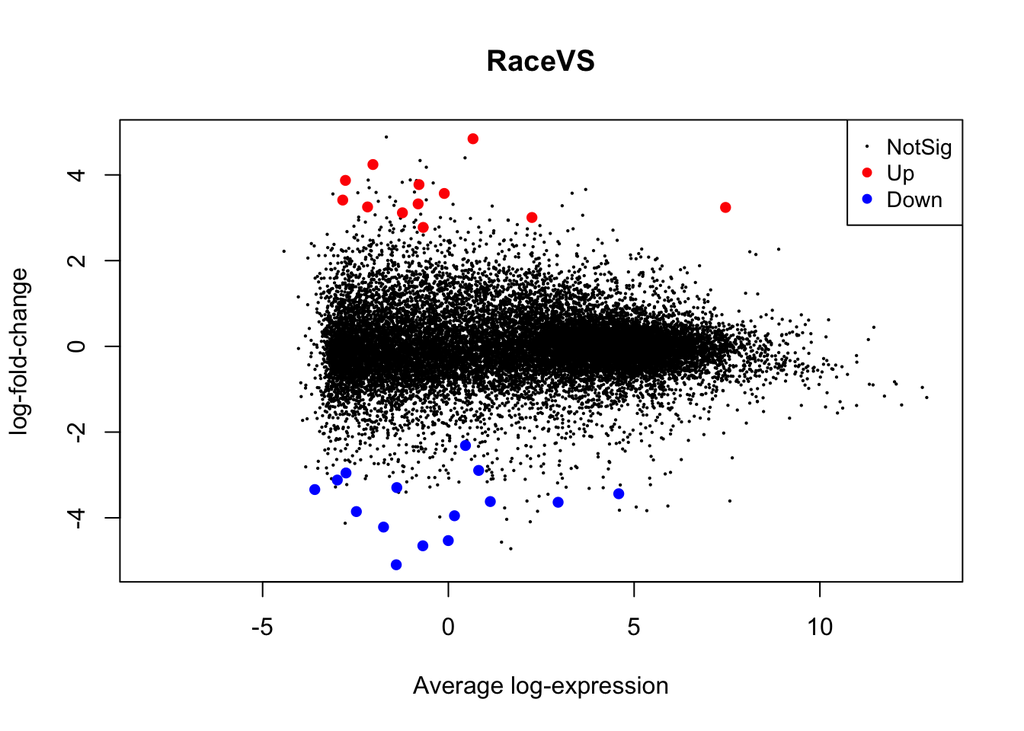

```r
# plotMD function
plotMD(tfit, column=1, status=dt[,1], main=colnames(tfit)[1],
       xlim=c(-8,13))
```

```r
#glMDPlot(tfit, coef=1, status=dt, main=colnames(tfit)[1],
         #side.main="ENSEMBL", counts=lcpm_male_only, groups=group_male_only, launch=FALSE)
```

**HeatMap**

- Heatmap of log-CPM values for top 100 genes DE in RaceVS (White vs Asian). Samples with relatively high expression of a given gene are shown in red and samples with relatively low expression are shown in blue. (Each row: a given gene; Each column: a sample). Lighter red/blue and white represent genes with intermediate expression levels. A dendrogram is shown for the sample clustering, which displays three main groups.
- [Discussion] From the heatmap, it is evident that these 60 males can be divided into three groups: from left 1 to 11, from left 12 to 21, and from left 22 to 30. Most Asian males(from left 12 to 21) and white males(from left 1 to 11) share similar gene expression patterns in their groups. The rest of these males(from left 22 to 30) show a relatively more disordered gene expression pattern than the other two groups.

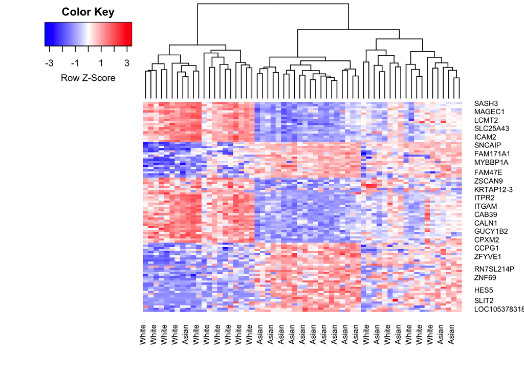

```r
# get heatmap of log-CPM values
library(gplots)
RaceVS.topgenes <- RaceVS$ENSEMBL[1:100]
i <- which(v$genes$ENSEMBL %in% RaceVS.topgenes)
mycol <- colorpanel(1000,"blue","white","red")
heatmap.2(lcpm_male_only[i,], scale="row",
   labRow=v$genes$SYMBOL[i], labCol=group_male_only,
   col=mycol, trace="none", density.info="none",
   lhei=NULL, dendrogram="column")
```

## Part 9 - Gene set testing with camera

```r
load('/Users/dongzeyuan/Desktop/zeyuan-510final/human_c2_v5p2.rdata')
#human_c2_v5p2.rdata is download from http://bioinf.wehi.edu.au/software/MSigDB/
idx <- ids2indices(Hs.c2,id=rownames(v$genes))
cam.RaceVS <- camera(v,idx,design,contrast=contr.matrix[,1])
head(cam.RaceVS,20)# look for appropriate hallmark gene sets
```

```
##                                                     NGenes Direction
## KEGG_ARACHIDONIC_ACID_METABOLISM                        42        Up
## BIOCARTA_TCRA_PATHWAY                                   10        Up
## WANG_BARRETTS_ESOPHAGUS_AND_ESOPHAGUS_CANCER_UP         16        Up
## STEIN_ESRRA_TARGETS_RESPONSIVE_TO_ESTROGEN_DN           24        Up
## CHIARADONNA_NEOPLASTIC_TRANSFORMATION_KRAS_CDC25_DN     36        Up
## KOBAYASHI_RESPONSE_TO_ROMIDEPSIN                         9        Up
## KEGG_ETHER_LIPID_METABOLISM                             18        Up
## BIOCARTA_IL17_PATHWAY                                   14        Up
## ODONNELL_TARGETS_OF_MYC_AND_TFRC_DN                     29        Up
## REACTOME_PI_METABOLISM                                  33        Up
## NIKOLSKY_BREAST_CANCER_7P15_AMPLICON                    11        Up
## VALK_AML_WITH_FLT3_ITD                                  25        Up
## REACTOME_UNWINDING_OF_DNA                                7        Up
## HONRADO_BREAST_CANCER_BRCA1_VS_BRCA2                    17        Up
## LEIN_LOCALIZED_TO_DISTAL_AND_PROXIMAL_DENDRITES          6        Up
## LIN_SILENCED_BY_TUMOR_MICROENVIRONMENT                  59        Up
## SARTIPY_BLUNTED_BY_INSULIN_RESISTANCE_UP                 9        Up
## PACHER_TARGETS_OF_IGF1_AND_IGF2_UP                      27        Up
## REACTOME_ACYL_CHAIN_REMODELLING_OF_PS                    7        Up
## WHITFIELD_CELL_CYCLE_LITERATURE                         37        Up
##                                                           PValue       FDR
## KEGG_ARACHIDONIC_ACID_METABOLISM                    3.764156e-05 0.1655476
## BIOCARTA_TCRA_PATHWAY                               1.705186e-04 0.2575530
## WANG_BARRETTS_ESOPHAGUS_AND_ESOPHAGUS_CANCER_UP     2.102091e-04 0.2575530
## STEIN_ESRRA_TARGETS_RESPONSIVE_TO_ESTROGEN_DN       2.342456e-04 0.2575530
## CHIARADONNA_NEOPLASTIC_TRANSFORMATION_KRAS_CDC25_DN 5.157754e-04 0.3921561
## KOBAYASHI_RESPONSE_TO_ROMIDEPSIN                    6.874951e-04 0.3921561
## KEGG_ETHER_LIPID_METABOLISM                         7.560312e-04 0.3921561
## BIOCARTA_IL17_PATHWAY                               8.461410e-04 0.3921561
## ODONNELL_TARGETS_OF_MYC_AND_TFRC_DN                 8.794413e-04 0.3921561
## REACTOME_PI_METABOLISM                              9.905638e-04 0.3921561
## NIKOLSKY_BREAST_CANCER_7P15_AMPLICON                1.101098e-03 0.3921561
## VALK_AML_WITH_FLT3_ITD                              1.233378e-03 0.3921561
## REACTOME_UNWINDING_OF_DNA                           1.280672e-03 0.3921561
## HONRADO_BREAST_CANCER_BRCA1_VS_BRCA2                1.398224e-03 0.3921561
## LEIN_LOCALIZED_TO_DISTAL_AND_PROXIMAL_DENDRITES     1.451895e-03 0.3921561
## LIN_SILENCED_BY_TUMOR_MICROENVIRONMENT              1.490335e-03 0.3921561
## SARTIPY_BLUNTED_BY_INSULIN_RESISTANCE_UP            1.729055e-03 0.3921561
## PACHER_TARGETS_OF_IGF1_AND_IGF2_UP                  1.830680e-03 0.3921561
## REACTOME_ACYL_CHAIN_REMODELLING_OF_PS               1.852089e-03 0.3921561
## WHITFIELD_CELL_CYCLE_LITERATURE                     1.991238e-03 0.3921561
```

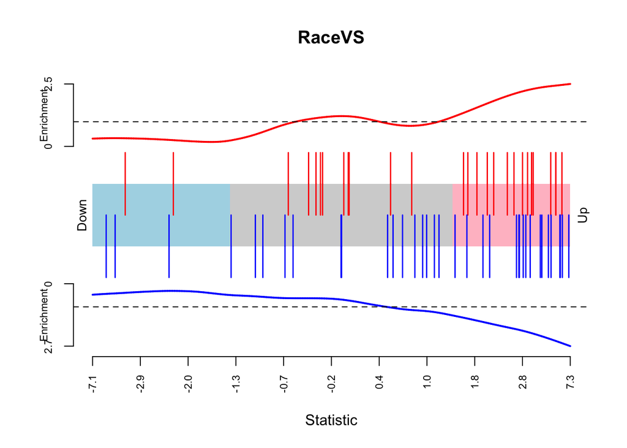

```r
# use camera function to perform a competitive test to assess whether the genes in a given set are highly ranked in terms of differential expression relative to genes that are not in the set.
barcodeplot(efit$t[,1], index=idx$PACHER_TARGETS_OF_IGF1_AND_IGF2_UP,
            index2=idx$CHIARADONNA_NEOPLASTIC_TRANSFORMATION_KRAS_CDC25_DN, main="RaceVS")
```